# Segmentation – Day 11: Data & Domain

**Student Name:** Traver Dinten **Country:** Switzerland **Semester term:** FS26

## Use Case

*Focus: domain and application context*

In the context of Swiss coffee quality control, images of roasted coffee beans are captured on sorting tables at processing facilities and used to assess batch consistency by counting individual beans and measuring their size and shape. Switzerland is the world's largest coffee trading hub — Nestlé (Nespresso, Nescafé) is headquartered in Vevey, and Zurich hosts one of the global centers for green and roasted coffee commodity trading. Automated visual inspection of bean batches supports grading, defect detection, and yield estimation across the Swiss coffee supply chain. Segmenting individual beans from the background enables reliable counting and quantitative property measurement without manual sorting.

## Problem Statement

*Focus: technical vulnerability*

This project addresses the problem of applying threshold-based segmentation to separate individual roasted coffee beans from a uniform background in order to count and measure them within the context of Swiss coffee quality inspection. The image contains multiple similar objects (beans) that must be reliably distinguished from the bright background to enable consistent counting and size measurement. If the segmentation threshold is chosen inadequately, beans may merge with each other or with background regions, leading to incorrect object counts and distorted area/perimeter measurements. Additionally, shadows cast by individual beans and slight intensity variations across the background surface may cause local misclassification. Preserving accurate object boundaries is essential for reliable bean counting and dimensional analysis in this quality control application.

## Experimental Objective

*Focus: investigation goal at the conceptual level*

The objective of this project is to investigate how threshold-based image segmentation can be used to reliably separate and extract individual coffee beans from a uniform background, in order to enable automated counting and dimensional measurement of beans within a quality control context. The goal is to determine under which segmentation conditions the individual objects are correctly isolated and their boundaries preserved sufficiently for quantitative property analysis.

## Data Definition, Source, and Visualization

*Focus: data characteristics, data source, and visual inspection*

The selected image is a top-view photograph of roasted coffee beans scattered on a white surface. The image was sourced from Pexels (Photo ID 942800, photographer Toni Cuenca), published under the Pexels license which permits free use for all purposes. The photograph was captured under controlled studio lighting conditions, resulting in a high-contrast scene with dark brown beans against a bright white background.

The image is stored locally as `data/raw/coffee_beans.jpg` and loaded as an 8-bit RGB image. The beans vary slightly in size and orientation, but share consistent visual characteristics: uniform dark brown coloration, elliptical to oval shape, and a characteristic central crease. The white background provides strong intensity contrast against the beans, making the image well-suited for intensity-based segmentation.

```python
import os
import numpy as np
import matplotlib.pyplot as plt
from skimage import io, color

DATA_DIR = os.path.join("..", "data", "raw")
FIGURES_DIR = os.path.join("..", "figures")
os.makedirs(FIGURES_DIR, exist_ok=True)

IMAGE_PATH = os.path.join(DATA_DIR, "coffee_beans.jpg")
img_rgb = io.imread(IMAGE_PATH)
img_gray = color.rgb2gray(img_rgb)

print(f"Image shape: {img_rgb.shape}")
print(f"Data type: {img_rgb.dtype}")
print(f"Pixel value range (RGB): [{img_rgb.min()}, {img_rgb.max()}]")
print(f"Grayscale range: [{img_gray.min():.3f}, {img_gray.max():.3f}]")
```

```
Image shape: (530, 800, 3)
Data type: uint8
Pixel value range (RGB): [0, 255]
Grayscale range: [0.003, 1.000]
```

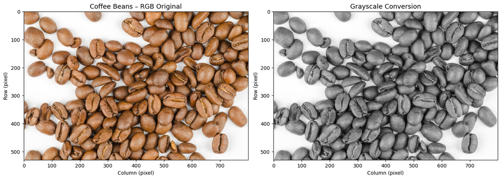

```python
fig, axes = plt.subplots(1, 2, figsize=(14, 6))

axes[0].imshow(img_rgb)
axes[0].set_title("Coffee Beans – RGB Original", fontsize=13)
axes[0].set_xlabel("Column (pixel)")
axes[0].set_ylabel("Row (pixel)")

axes[1].imshow(img_gray, cmap="gray")
axes[1].set_title("Grayscale Conversion", fontsize=13)
axes[1].set_xlabel("Column (pixel)")
axes[1].set_ylabel("Row (pixel)")

plt.tight_layout()
plt.savefig(os.path.join(FIGURES_DIR, "day11_original.png"), dpi=150, bbox_inches="tight")
plt.show()
```

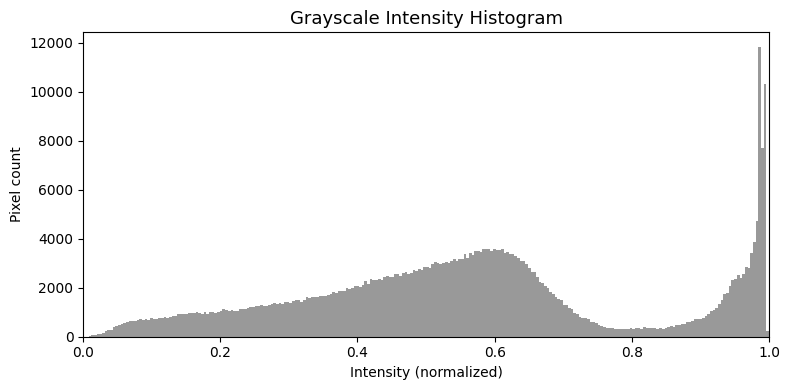

```python
fig, ax = plt.subplots(figsize=(8, 4))
ax.hist(img_gray.ravel(), bins=256, range=(0, 1), color="gray", edgecolor="none", alpha=0.8)
ax.set_title("Grayscale Intensity Histogram", fontsize=13)
ax.set_xlabel("Intensity (normalized)")
ax.set_ylabel("Pixel count")
ax.set_xlim(0, 1)
plt.tight_layout()
plt.savefig(os.path.join(FIGURES_DIR, "day11_histogram.png"), dpi=150, bbox_inches="tight")
plt.show()
```

## Object Definition and Segmentation Objective

**What constitutes an object:**

An object in this image is defined as a single, individual roasted coffee bean — a spatially contiguous dark region that is visually separable from the white background. Each bean corresponds to one physical unit. Touching beans that cannot be spatially separated by intensity-based methods alone may be treated as a single merged object, with morphological refinement or watershed-based post-processing as potential strategies for later separation.

**Objective of segmentation:**

The primary objectives of segmentation in this context are:

1. **Counting:** Determine the total number of individual beans visible in the image. Accurate counting is the baseline requirement for batch size estimation in quality control.
2. **Measuring:** Extract quantitative properties of each segmented bean, including area (in pixels), perimeter, and eccentricity. These measurements enable assessment of size consistency within the batch — a key quality indicator in coffee grading.

No segmentation methods, threshold selection strategies, or morphological operations are introduced at this stage. The methodological design for segmentation will be developed in Day 12.